# A5: Incarceration

### Introduction

It is important to know the different proportions found across different state/counties concerning the difference between population and what amount of that population is in jails and what amount of those prisoners are black to justify what counties may be more dangerous or what cities are more likely to incarcerate black criminals. That is why I am choosing to analyze the current (2018) total population from 15 to 64 to represent the population that can legally be incarcerated of each state/county. I am also choosing to analyze the current (2018) total jail population of each state/county to help find the proportions between the county population and its jail population. The last variable I will analyze is the black jail population to compare it with the populations of jails and counties to compare differences and determine possible unfair/disproportionate numbers of incarcerated black citizens.

Dataset: https://github.com/melaniewalsh/Neat-Datasets/blob/main/us-jail-pop.csv?raw=true

### Summary Information

In order to have a grasp of what the proportions may look like, it will be important to know what the largest and smallest counties are. The county with the highest total population from 15 to 64 is Los Angeles County with 6911101 as of 2018. The county with the lowest total population from 15 to 64 is Wade Hampton Census Area with 0 as of 2018. Another piece of data that will be important is the number of people that are found in jails which I will simply summarize for now by finding the mean. The average current total jail population per county is 248.945 as of 2018. Lastly, it is important to know the number of black people that are found in jails to discover any unfair/disproportionate incarceration of black citizens. The county with the highest total black people in jail is Los Angeles County with 5024 and the lowest was Bethel Census Area with 0 (both in 2018). All summary statistics were found using functions that can be seen in summary.R.

### The Dataset

*Who collected the data?* The data was collected by Vera Institute.

*How was the data collected or generated?* Vera Institute gathers their data through various methods and sources such as governmenal agencies, public records, surveys/interviews, other research institutions, data aggregation, and open data initiatives. More specifically for the jails data, they collected the data from the Annual Survey of Jails (ASJ), Census of Jails (COJ), and population and separate variables from Death in Custody Reporting Program DCRP.

*Why was the data collected?* The data was collected because Vera Institute strives to research, test, and scale innovative solutions to end mass incarceration, leading to the collection of data such as this.

*How many observations (rows) are in your data?* There are 153811 rows.

*How many features (columns) are in the data?* There are 28 columns.

*What, if any, ethical questions or questions of power do you need to consider when working with this data?* One question I have regarding ethics is whether or not the race of the person is self-reported or one they had assumed. Since subjects such as race is becoming more liquid, I think that the data regarding race can be somewhat unreliable and a possible result of racial profiling. Other than that, since it is data primarily reflecting population/numbers of people, there are no other concerns regarding ethics.

*What are possible limitations or problems with this data? (at least 200 words)* A limitation/problem of the dataset is the sheer amount of missing data present. There are a lot of values that are seen as ‘NA’ and I even had to switch over from the “Dataset about prison population per county/state” to the “Dataset about jail population per county/state” since the first one kept leading to errors and printing ‘NaN’ whenever I tried to calculate averages. Due to these errors and the large amounts of missing data points, it is hard to say whether or not it is reliable and solid enough of a source to support a substantial case on the topic of racially disproportionate incarcerations.

### Trends Over Time Chart

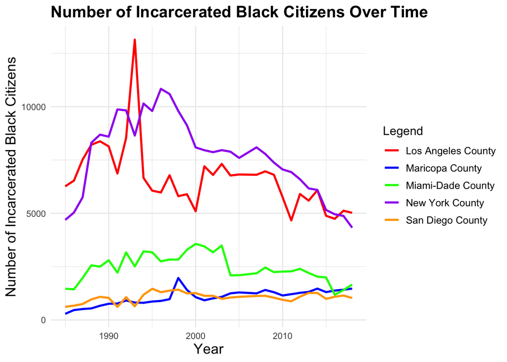

### Variable Comparison Chart

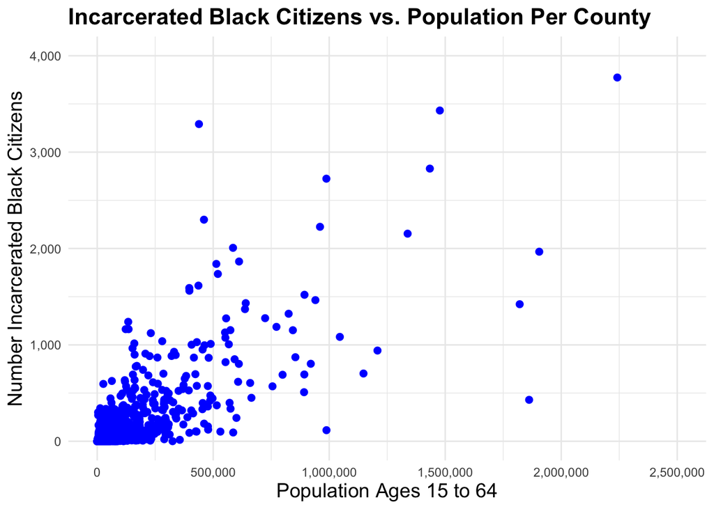

### Map

This map illustrates the distribution of black people in jail across the United States using the total number across all counties for each state in 2018. I included this chart because it helps illustrate the different amounts of incarcerated black citizens distributed across all the different states. California, by far, has the highest black jail population with Texas coming in second at just above 30,000,000. Other than New York and Florida, there are no other states above the 20,000,000 mark. Looking at the map, states such as Idaho, Montana, Dakota, Maine, and a few other states have incredibly small numbers of incarcerated black citizens.

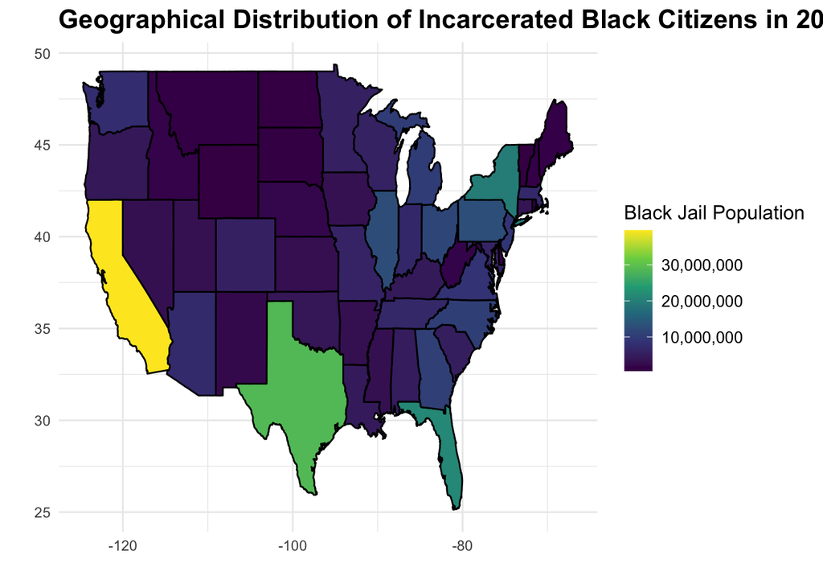